# Topic 8. Electoral College Predictions

Josh Clinton

8/20/2021

First load the data of all state-level polls for the 2020 presidential election.

```r
load(file="data/Pres2020.StatePolls.Rdata")
glimpse(Pres2020.StatePolls)
```

```
## Rows: 1,545
## Columns: 19
## $ StartDate      <date> 2020-03-21, 2020-03-24, 2020-03-24, 2020-03-28, 2020-0…
## $ EndDate        <date> 2020-03-30, 2020-04-03, 2020-03-29, 2020-03-29, 2020-0…
## $ DaysinField    <dbl> 10, 11, 6, 2, 3, 5, 2, 2, 7, 3, 3, 3, 2, 2, 3, 4, 10, 1…
## $ MoE            <dbl> 2.8, 3.0, 4.2, NA, 4.0, 1.7, 3.0, 3.1, 4.1, 4.4, NA, NA…
## $ Mode           <chr> "Phone/Online", "Phone/Online", "Live phone - RDD", "Li…
## $ SampleSize     <dbl> 1331, 1000, 813, 962, 602, 3244, 1035, 1019, 583, 500, …
## $ Biden          <dbl> 41, 47, 48, 67, 46, 46, 46, 48, 52, 42, 48, 50, 52, 38,…
## $ Trump          <dbl> 46, 34, 45, 29, 46, 40, 48, 45, 39, 49, 47, 41, 43, 49,…
## $ Winner         <chr> "Rep", "Dem", "Dem", "Dem", "Dem", "Rep", "Dem", "Dem",…
## $ poll.predicted <dbl> 1, 1, 1, 1, 0, 0, 0, 1, 1, 1, 1, 1, 1, 1, 1, 1, 1, 1, 1…
## $ Funded         <chr> "UtahPolicy.com & KUTV 2News", "Sacred Heart University…
## $ Conducted      <chr> "Y2 Analytics", "GreatBlue Research", "LHK Partners Inc…
## $ margin         <dbl> -5, 13, 3, 38, 0, 6, -2, 3, 13, -7, 1, 9, 9, -11, 6, -1…
## $ DaysToED       <drtn> 218 days, 214 days, 219 days, 219 days, 216 days, 213 …
## $ StateName      <chr> "Utah", "Connecticut", "Wisconsin", "California", "Mich…
## $ EV             <int> 6, 7, 10, 55, 16, 29, 16, 16, 12, 15, 10, 16, 11, 6, 16…
## $ State          <chr> "UT", "CT", "WI", "CA", "MI", "FL", "GA", "MI", "WA", "…
## $ BidenCertVote  <dbl> 38, 59, 49, 64, 51, 48, 50, 51, 58, 49, 49, 51, 49, 41,…
## $ TrumpCertVote  <dbl> 58, 39, 49, 34, 48, 51, 49, 48, 39, 50, 49, 48, 49, 58,…
```

Variables of potential interest include:

- *Biden* : Percentage of respondents supporting Biden, the Democrat, in poll (0-100)
- *Trump* : Percentage of respondents supporting Trump, the Republican, in poll (0-100)
- *BidenCertVote* : Percentage of vote Biden, the Democrat, actually received in the election (0-100)
- *TrumpCertVote* : Percentage of vote Trumo, the Democrat, actually received in the election (0-100)
- *Winner* : whether Biden won (“Dem”) or Trump won (“Rep”)
- *poll.predicted* : Indicator for whether the poll correctly predicted who won (1) or not (0)
- *State* & *StateName* : the state where the poll was conducted
- *EV* : the number of Electoral College Votes the state is worth for the winning candidate

# Overall Task:

- How do we use this data to calculate the probability that Biden will win the presidency of the United States by winning the Electoral College?

### Task 1: How should we translate a poll result into a predicted probability?

Suppose that I give you 10 polls from a state. How can you use them to create a probability? Discuss! (I can think of 3 ways.)

- Fraction of polls with Biden in the lead
- Biden Pct = Probability Biden wins
- Normalized Biden Pct = Probability Biden wins

```r
Pres2020.StatePolls <- Pres2020.StatePolls %>%
   mutate(BidenNorm = Biden/(Biden+Trump),
          TrumpNorm = 1-BidenNorm)
```

### Task 2: Start “simple” – calculate the probability that Biden wins PA

- Create a tibble with just polls from PA.

```r
PA.dat <- Pres2020.StatePolls %>%
  filter(State == "PA")
```

- Now compute that probability (or those probabilities). What functions do we need?

```r
PA.dat %>%
      summarize(BidenProbWin1 = mean(Biden > Trump),
                BidenProbWin2 = mean(Biden/100),
                BidenProbWin3 = mean(BidenNorm))
```

```
## # A tibble: 1 × 3
##   BidenProbWin1 BidenProbWin2 BidenProbWin3
##           <dbl>         <dbl>         <dbl>
## 1         0.916         0.499         0.529
```

- What do you think about this?

### Task 3: Given that probability, how do we change the code to compute the expected number of Electoral College Votes `EV` for Biden?

- Keep the code from above and copy and paste so you can understand how each step changes what we are doing.

```r
PA.dat %>%
      summarize(BidenProbWin1 = mean(Biden > Trump),
                BidenProbWin2 = mean(Biden/100),
                BidenProbWin3 = mean(BidenNorm),
                EV = mean(EV)) %>%
      mutate(BidenEV1 = BidenProbWin1*EV,
             BidenEV2 = BidenProbWin2*EV,
             BidenEV3 = BidenProbWin3*EV)
```

```
## # A tibble: 1 × 7
##   BidenProbWin1 BidenProbWin2 BidenProbWin3    EV BidenEV1 BidenEV2 BidenEV3
##           <dbl>         <dbl>         <dbl> <dbl>    <dbl>    <dbl>    <dbl>
## 1         0.916         0.499         0.529    20     18.3     9.98     10.6
```

### Task 3B: How get expected Electoral College votes for Trump?

- NOTE: There are at least 2 ways to do this because this is a 2 candidate race
- `EV-BidenEV`, or compute `TrumpProbWin`

### Task 4: Now generalize to every state by applying this code to each set of state polls.

- What do we need to do this calculation for every state in our tibble?
- First, compute probability of winning a state. (How?)
- Second, compute expected Electoral College Votes. (How?)

```r
Pres2020.StatePolls %>%
  group_by(StateName) %>%
    summarize(BidenProbWin1 = mean(Biden > Trump),
              BidenProbWin3 = mean(BidenNorm),
              EV = mean(EV),
              State = first(State)) %>%
    mutate(State = State,
              BidenECVPredicted1 = EV*BidenProbWin1,
              TrumpECVPredicted1 = EV- BidenECVPredicted1,
              BidenECVPredicted3 = EV*BidenProbWin3,
              TrumpECVPredicted3 = EV- BidenECVPredicted3)
```

```
## # A tibble: 50 × 9
##    StateName   BidenProbWin1 BidenProbWin3    EV State BidenECVPredicted1
##    <chr>               <dbl>         <dbl> <dbl> <chr>              <dbl>
##  1 Alabama             0             0.407     9 AL                  0
##  2 Alaska              0             0.466     3 AK                  0
##  3 Arizona             0.840         0.519    11 AZ                  9.24
##  4 Arkansas            0             0.395     6 AR                  0
##  5 California          1             0.661    55 CA                 55
##  6 Colorado            1             0.571     9 CO                  9
##  7 Connecticut         1             0.631     7 CT                  7
##  8 Delaware            1             0.627     3 DE                  3
##  9 Florida             0.798         0.517    29 FL                 23.2
## 10 Georgia             0.548         0.504    16 GA                  8.77
## # … with 40 more rows, and 3 more variables: TrumpECVPredicted1 <dbl>,
## #   BidenECVPredicted3 <dbl>, TrumpECVPredicted3 <dbl>
```

### Task 5: Now compute total expected vote by adding to that code

- NOTE: Actually 306 - 232
- What do we need to do to the tibble we created in Task 4 to get the overall number of Electoral College Votes?

```r
Pres2020.StatePolls %>%
  group_by(StateName) %>%
    summarize(BidenProbWin1 = mean(Biden > Trump),
              BidenProbWin3 = mean(BidenNorm),
              EV = mean(EV)) %>%
    mutate(BidenECVPredicted1 = EV*BidenProbWin1,
              TrumpECVPredicted1 = EV- BidenECVPredicted1,
              BidenECVPredicted3 = EV*BidenProbWin3,
              TrumpECVPredicted3 = EV- BidenECVPredicted3) %>%
    summarize(BidenECV1 = sum(BidenECVPredicted1),
              TrumpECV1 = sum(TrumpECVPredicted1),
              BidenECV3 = sum(BidenECVPredicted3),
              TrumpECV3 = sum(TrumpECVPredicted3))
```

```
## # A tibble: 1 × 4
##   BidenECV1 TrumpECV1 BidenECV3 TrumpECV3
##       <dbl>     <dbl>     <dbl>     <dbl>
## 1      345.      190.      289.      246.
```

- Could also do this for just polls conducted in the last X days. How?

# So far we have taken polls as fixed. What if we allow randomnesss via resampling?

### Start “simple”: probability that Biden wins PA

- Create a tibble with just PA to simplify

```r
PA.dat <- Pres2020.StatePolls %>%
  filter(State == "PA")
```

Write a loop that, for each iteration….

- Draws a sample of the same number of polls as were done in PA using `sample_n`
- Calculates the probability of a win using measures just discussed

But before you start, how does this differ from what we did previously with the PA data? What do we need to add to the code?

```r
ProbBidenWin.PA <- NULL
NSamples <- 1000

for(i in 1:NSamples){
    ProbBidenWin.PA <- PA.dat %>%
      sample_n(nrow(PA.dat),replace = TRUE) %>%
      summarize(BidenProbWin1 = mean(Biden > Trump),
                BidenProbWin2 = mean(Biden/100),
                BidenProbWin3 = mean(BidenNorm)) %>%
      bind_rows(ProbBidenWin.PA)
}
```

### Compute probability that Biden wins and the range containing 95% of the expected means (if we were to redo everything exactly as is).

```r
ProbBidenWin.PA %>%
  summarize(LCI1 = quantile(BidenProbWin1,.025),
            ProbWin1 = mean(BidenProbWin1),
            UCI1 = quantile(BidenProbWin1,.975),
            LCI3 = quantile(BidenProbWin3,.025),
            ProbWin3 = mean(BidenProbWin3),
            UCI3 = quantile(BidenProbWin3,.975))
```

```
## # A tibble: 1 × 6
##    LCI1 ProbWin1  UCI1  LCI3 ProbWin3  UCI3
##   <dbl>    <dbl> <dbl> <dbl>    <dbl> <dbl>
## 1 0.874    0.917 0.958 0.526    0.529 0.532
```

### Can you do this for Wisconsin?

- Take it from start to finish for a different state

## Now do this for all the states!

- Let us draw a new sample of 1545 state-level polls and go…

```r
ElectoralCollegeVotes <- NULL
B <- 100

for(i in 1:B){
  dat <- sample_n(Pres2020.StatePolls,
                  nrow(Pres2020.StatePolls),
                  replace=TRUE)

  ElectoralCollegeVotes <- dat %>%
  group_by(StateName) %>%
    summarize(BidenProbWin1 = mean(Biden > Trump),
              BidenProbWin2 = mean(Biden/100),
              BidenProbWin3 = mean(BidenNorm),
              EV = mean(EV)) %>%
    mutate(BidenECVExpected1 = BidenProbWin1*EV,
           TrumpECVExpected1 = EV - BidenECVExpected1,
           BidenECVExpected3 = BidenProbWin3*EV,
           TrumpECVExpected3 = EV - BidenECVExpected3) %>%
    summarize(BidenECV1 = sum(BidenECVExpected1),
              TrumpECV1 = sum(TrumpECVExpected1),
              BidenECV3 = sum(BidenECVExpected3),
              TrumpECV3 = sum(TrumpECVExpected3)) %>%
    bind_rows(ElectoralCollegeVotes)
}
```

### So what is the probability Biden gets at least 270 Electoral College Votes?

```r
 ElectoralCollegeVotes %>%
    summarize(BidenWin1 = mean(BidenECV1 > 270),
              BidenWin3 = mean(BidenECV3 > 270))
```

```
## # A tibble: 1 × 2
##   BidenWin1 BidenWin3
##       <dbl>     <dbl>
## 1         1         1
```

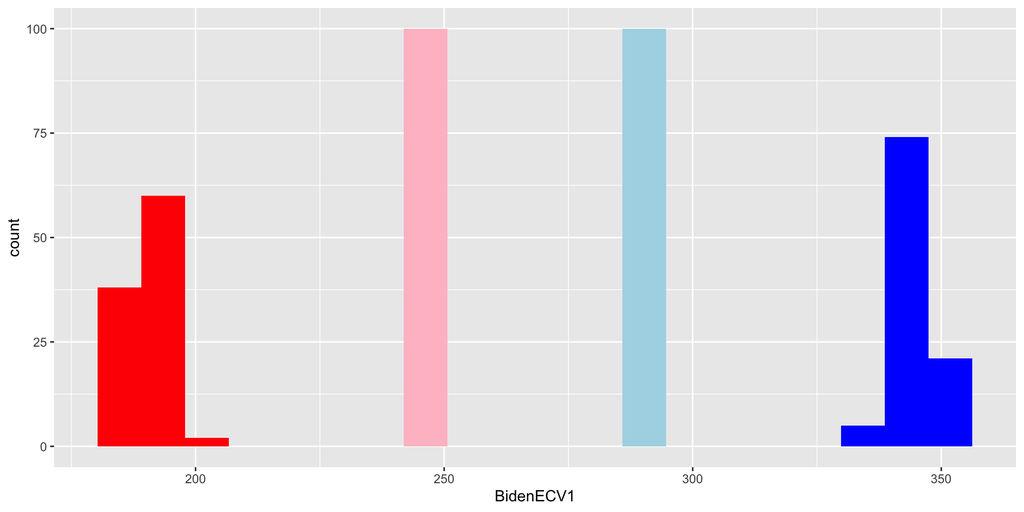

```r
ggplot(ElectoralCollegeVotes) +
  geom_histogram(aes(x=BidenECV1), fill= "BLUE",bins=20)+
  geom_histogram(aes(x=TrumpECV1), fill= "RED",bins=20) +
  geom_histogram(aes(x=BidenECV3), fill= "light blue",bins=20)+
  geom_histogram(aes(x=TrumpECV3), fill= "pink",bins=20)
```

# What is going on here? Why do our estimates not contain the true outcome?

- We assumed individual polls were fixed, but those are uncertain too!
- Assumption of random sampling in polling? Are respondents a random sample of voters?
- Assumption of random sampling in bootstrapping – are poll results in an election really independent? Or are outcomes correlated?

## Outstanding questions in terms of:

- Data collection (sampling and recruitment of respondents)
- Data analysis (Which measure of probability do you use? How quantify uncertainty?)